# Montréal car crashes since 2012

Linnea Soli

## Collisions over time

**Since 2012, total collisions in Montreal have been steadily decreasing in frequency.** Collisions in Montreal are defined as any accident from multi-party crashes to single-party crashes (such as a collision with a tree) to accidents which don’t involve a crash at all, for example an incident in which a vehicle’s engine explodes.

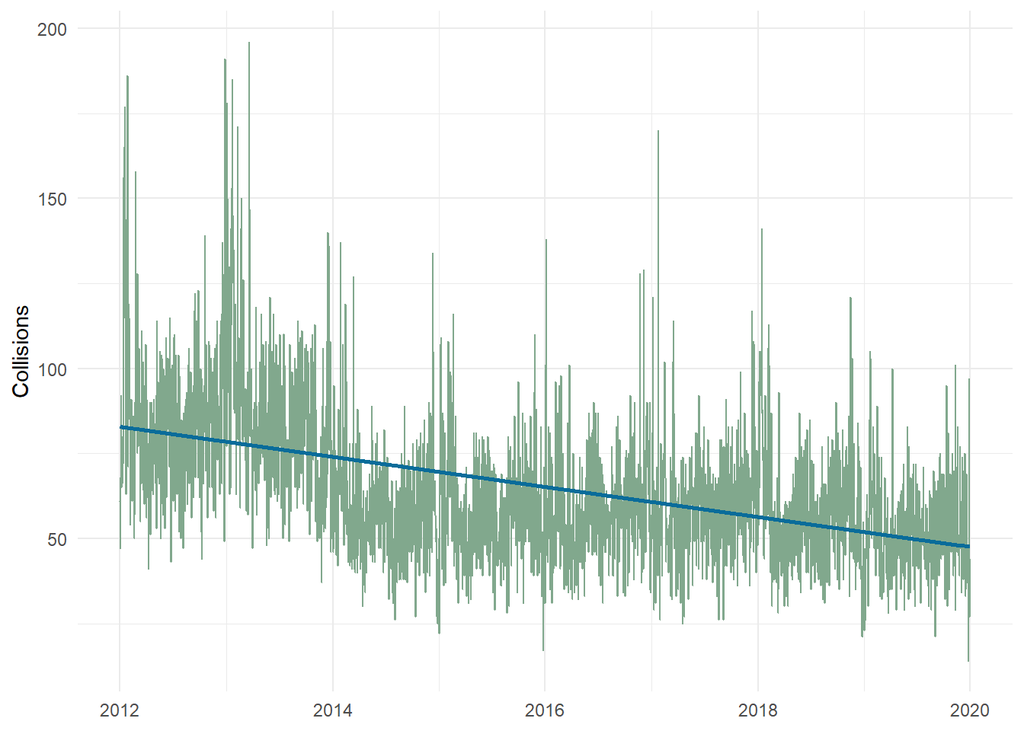

## When are collisions most likely?

**Collisions are most likely to occur around “rush hours” and during weekdays.** Peak travel times, when more commuters are on the roads, increase the likelihood of a collision occurring. In Montreal, **collisions occur most often during the month of January** however **serious or fatal collisions are more common during the warmer months, with most occuring during September**. We can also observe more collisions with cyclists in these warm months, when the weather permits more folks to comfortably be out on their bikes.

### By time of day

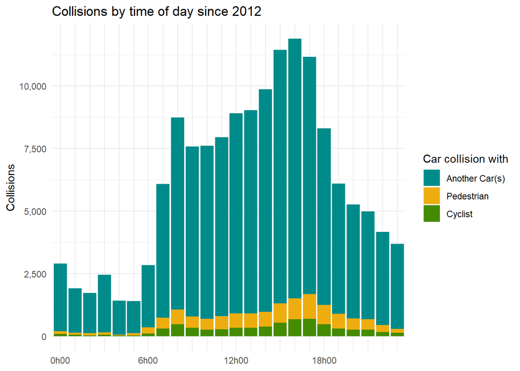

### By day of the week

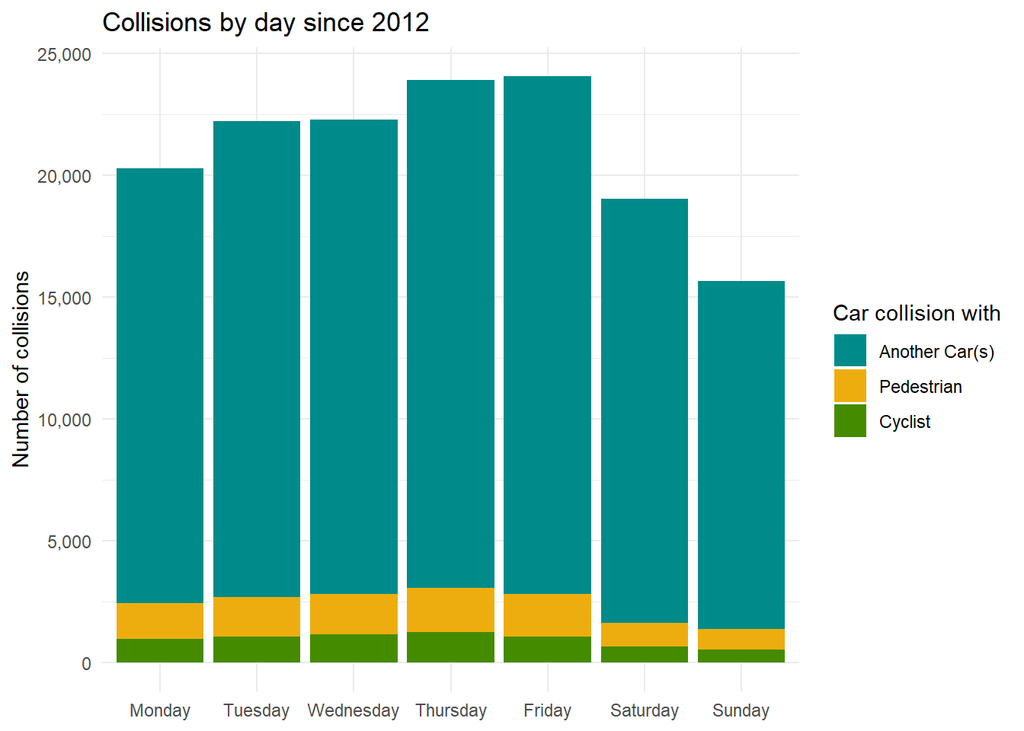

### By month

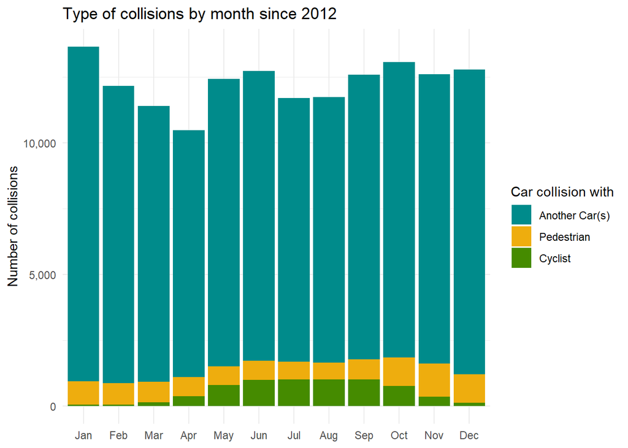

## Who is affected by collisions?

### Collision type

Over 75% of all collisions between vehicles since 2012 have resulted in material damage alone. Conversely, vehicle collisions with pedestrian and cyclists primarily result in at least person sustaining light injuries. Collisions between vehicles and pedestrians are more often serious or fatal than inter-vehicle crashes, with pedestrians proving the most vulnerable to a severe or fatal incident.

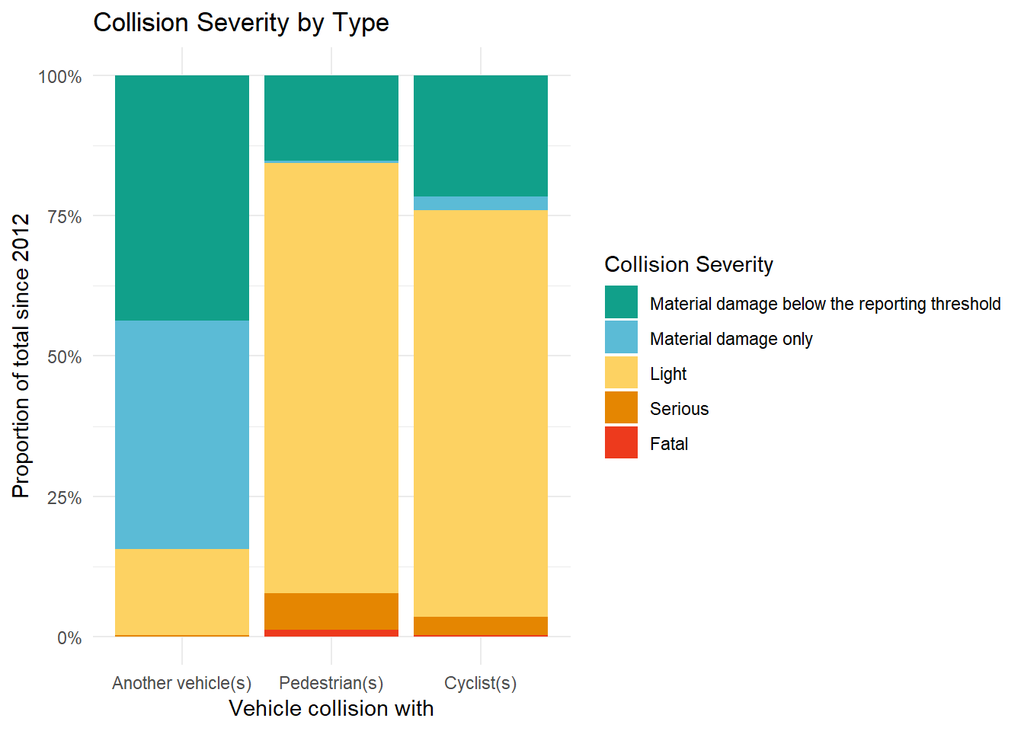

## The demographics of collisions

### 2019

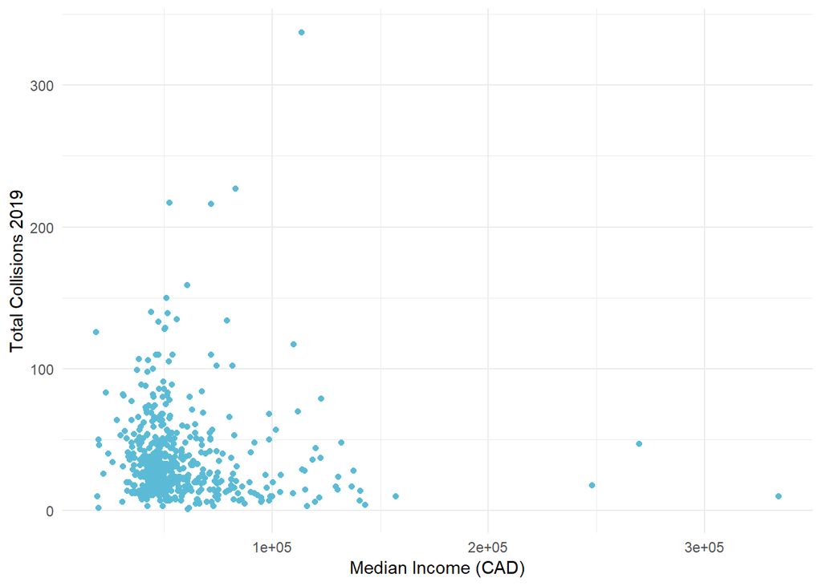

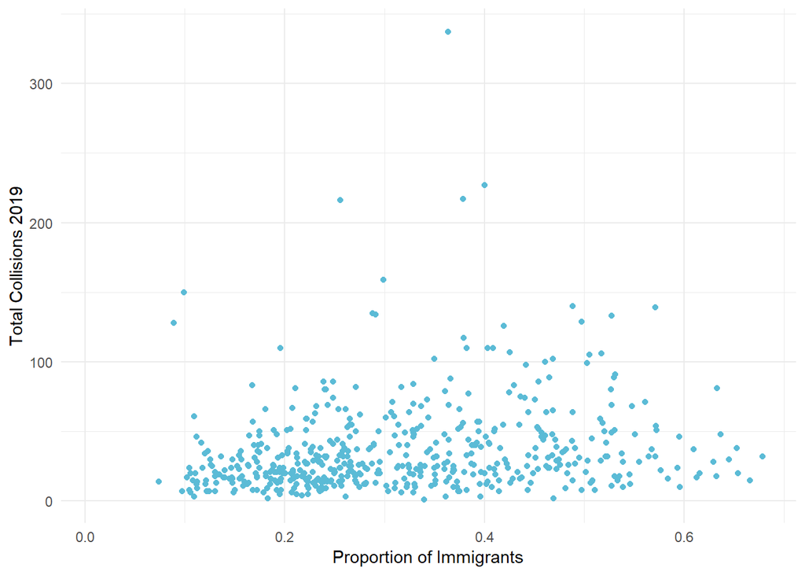

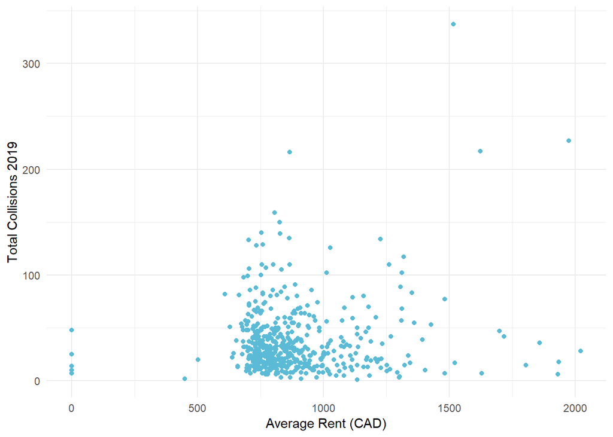

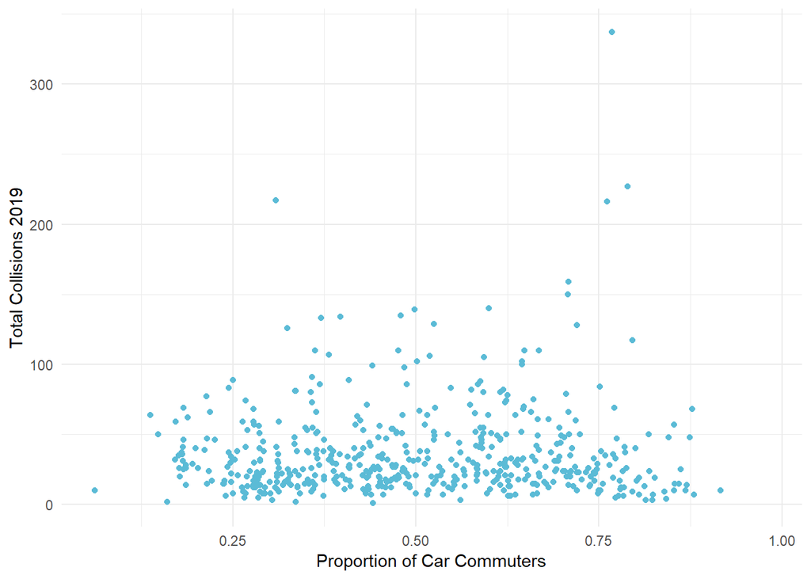

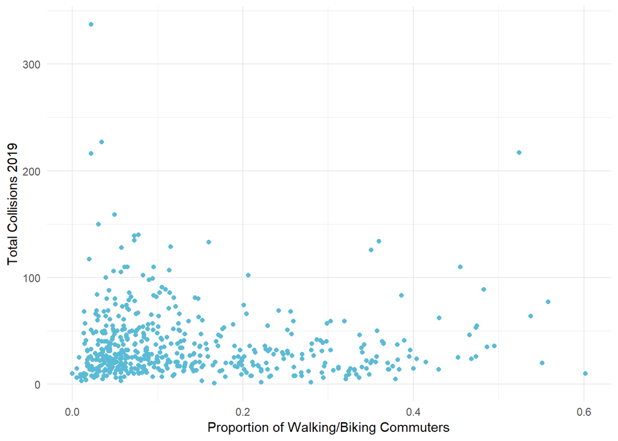

### 2018

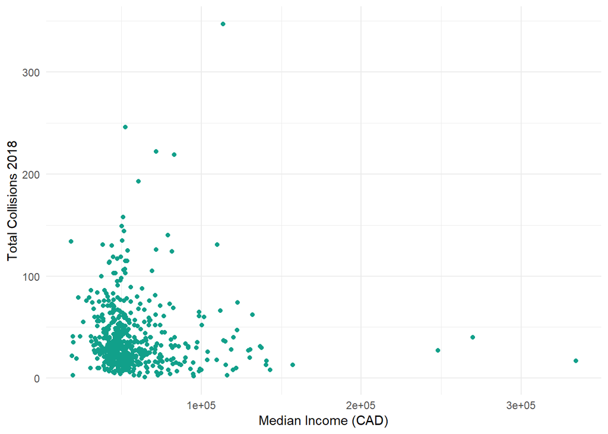

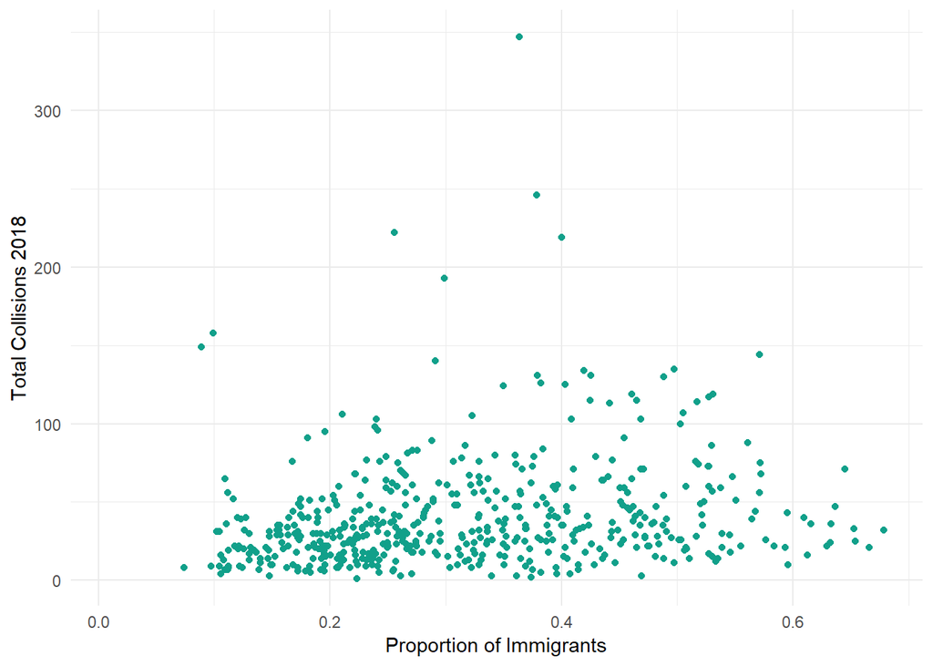

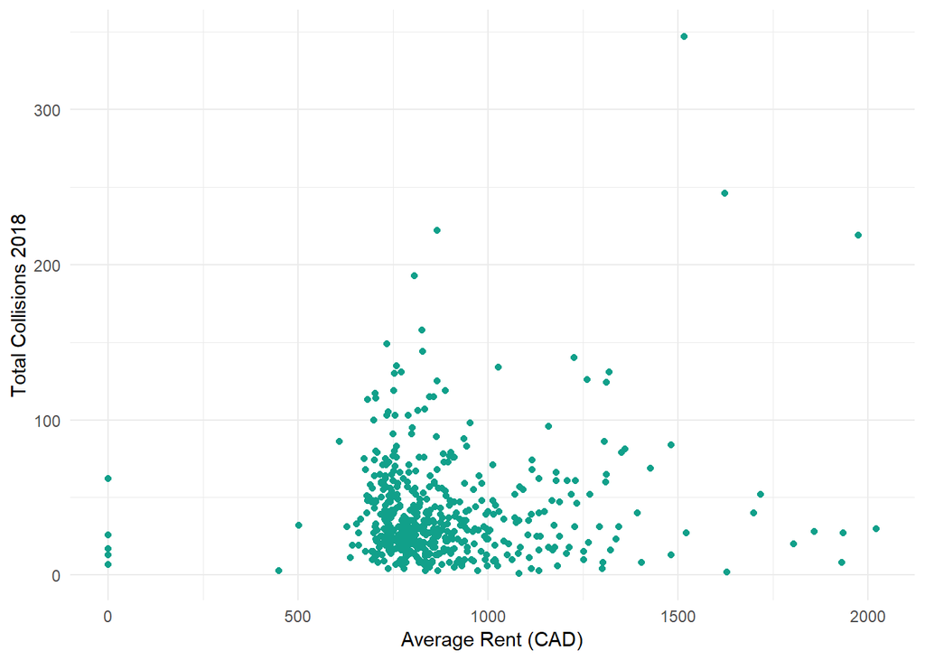

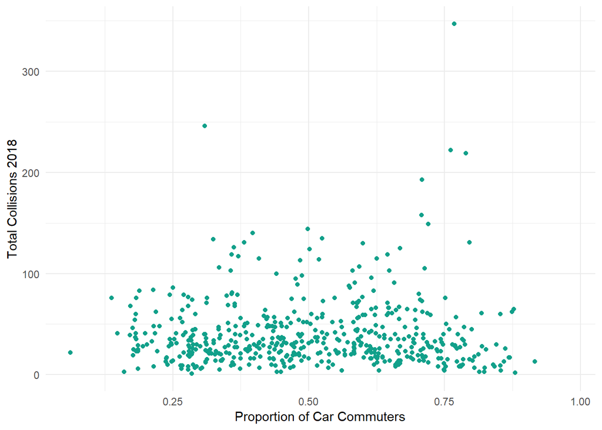

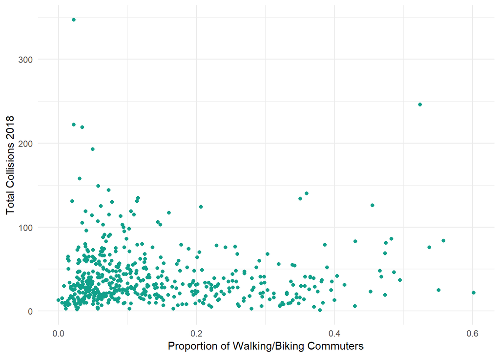

### 2017

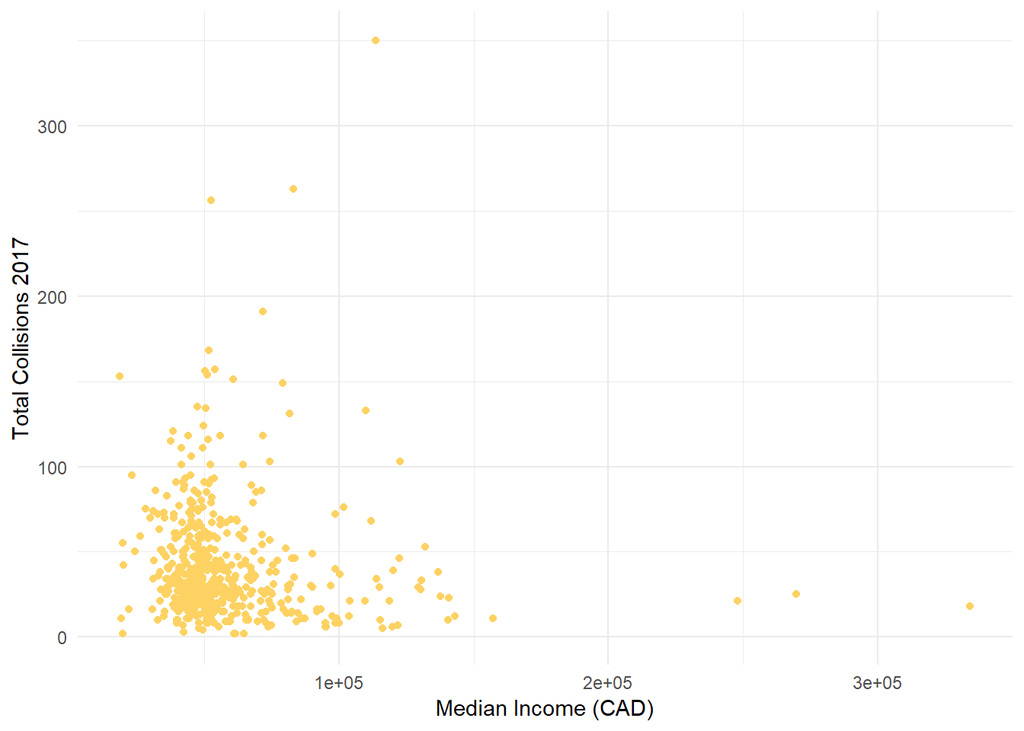

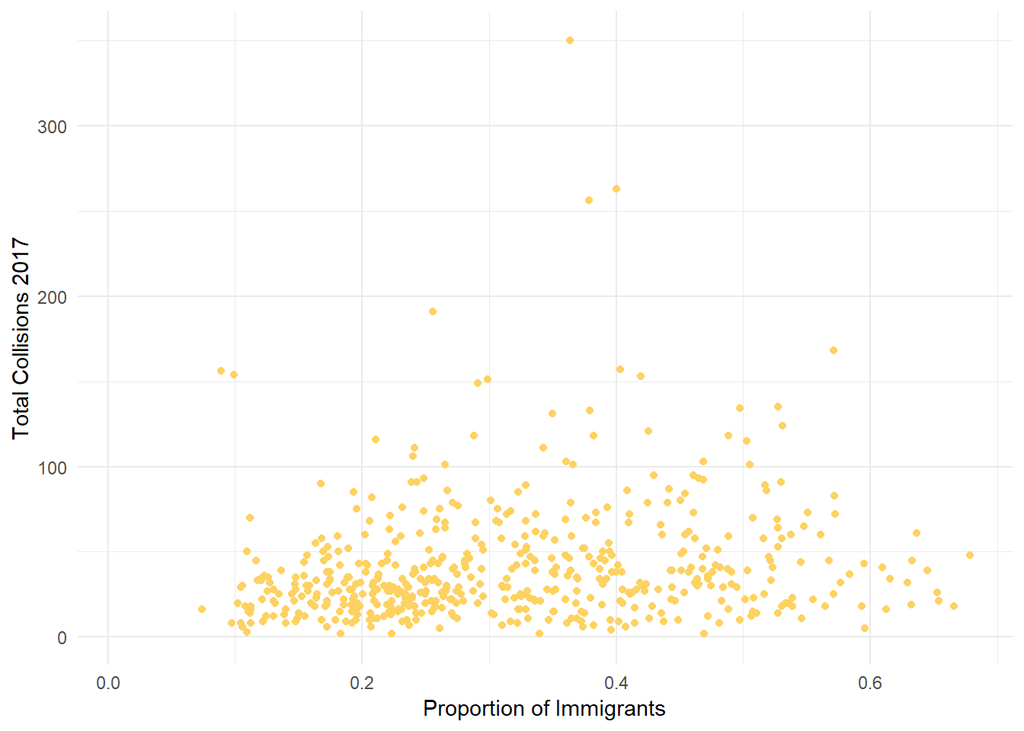

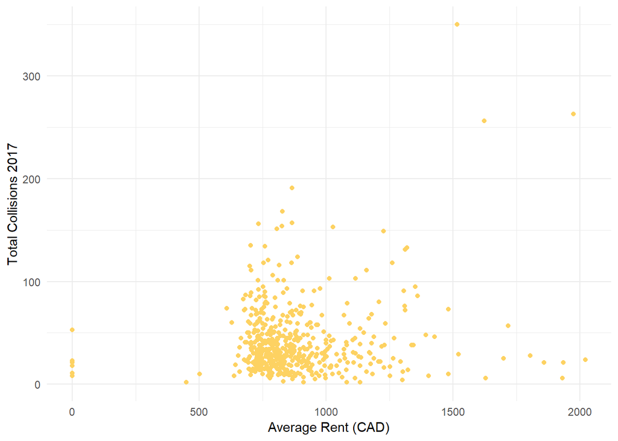

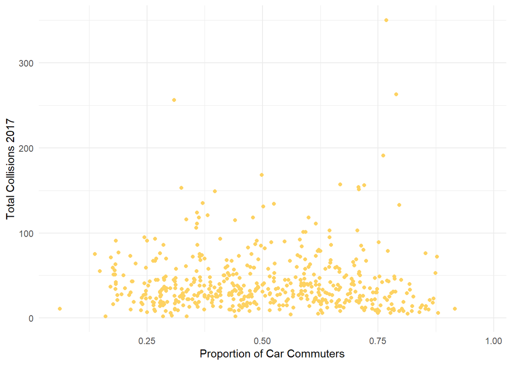

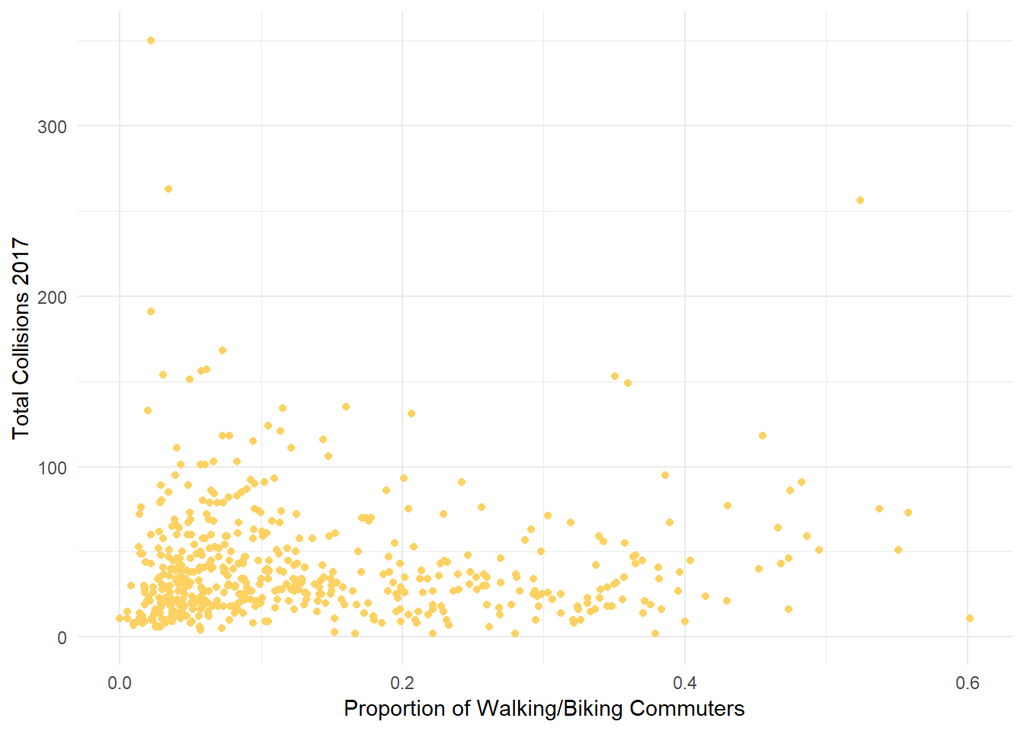

### 2016

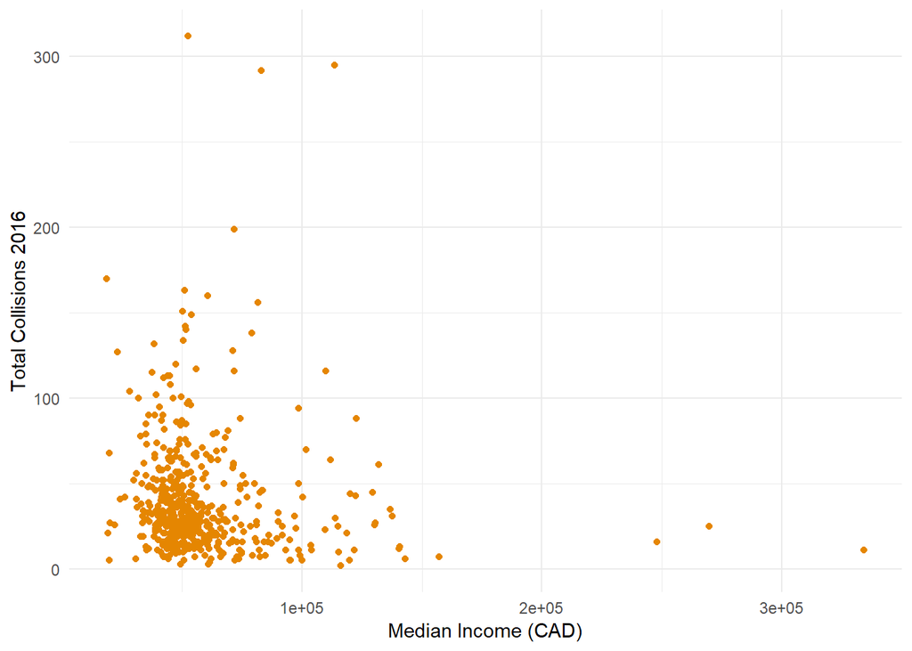

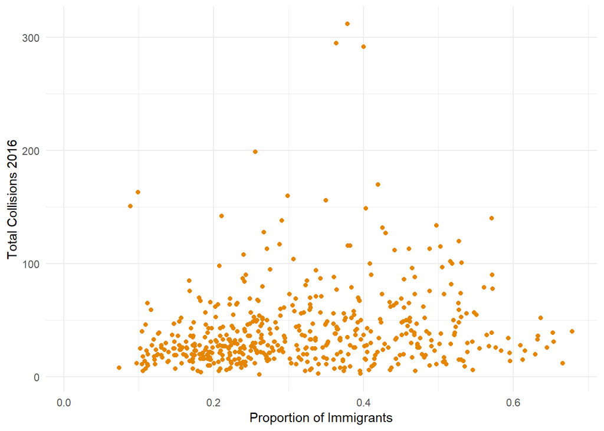

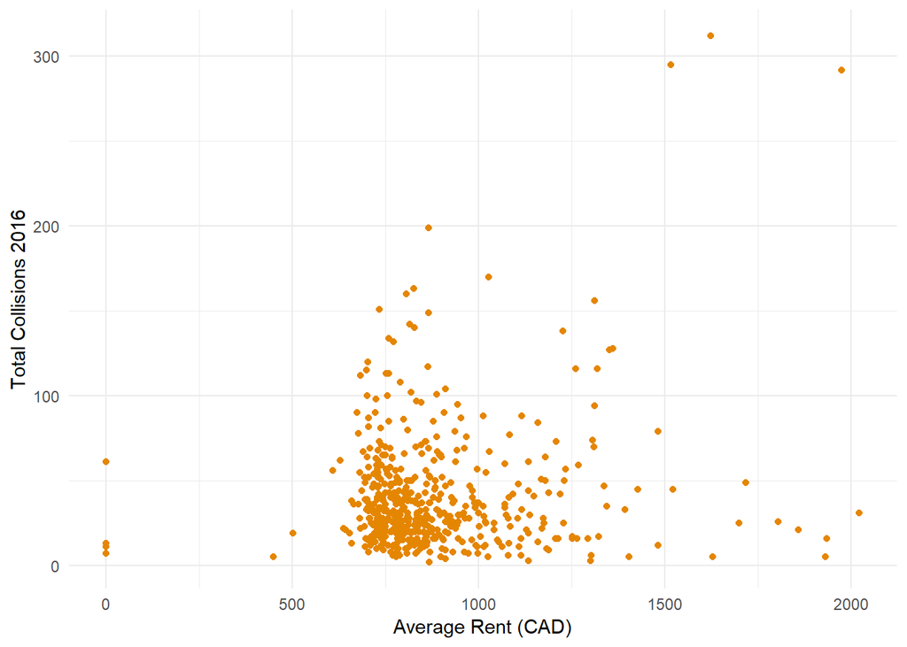

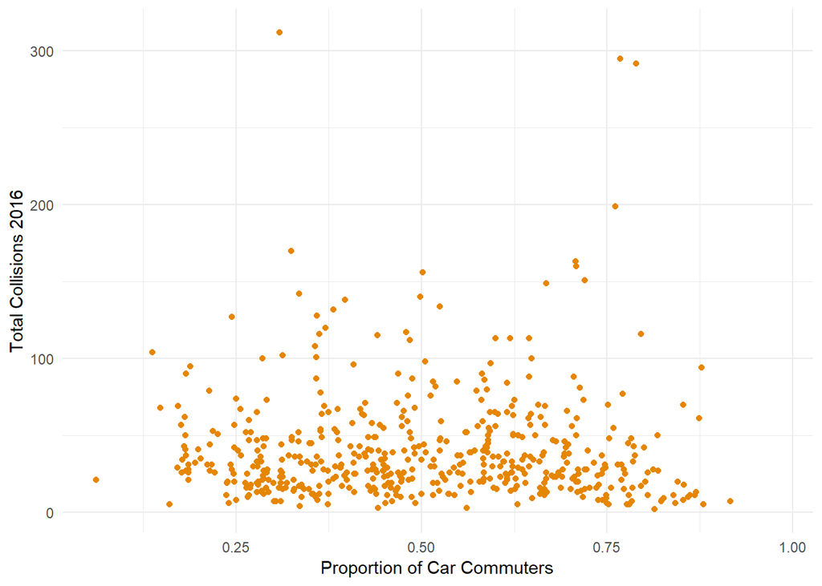

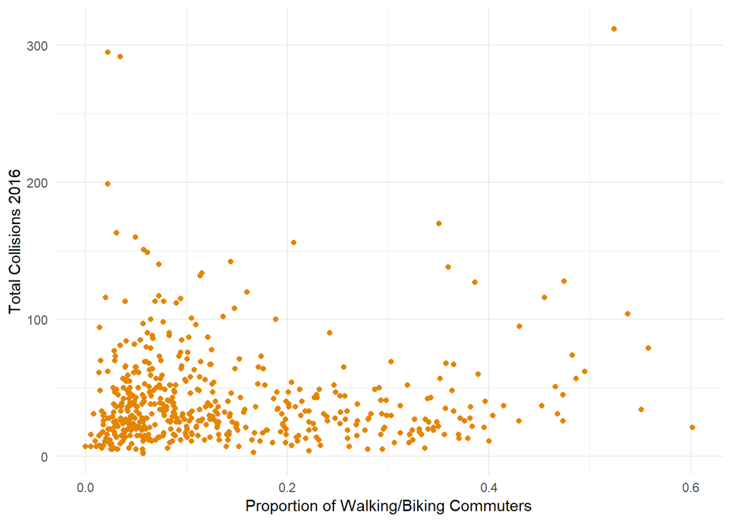

### 2015

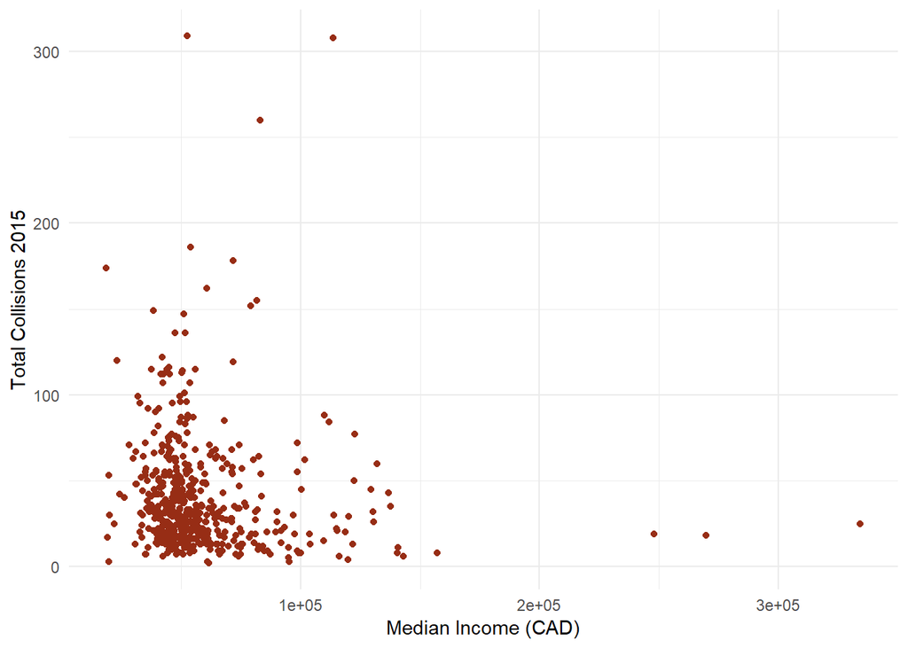

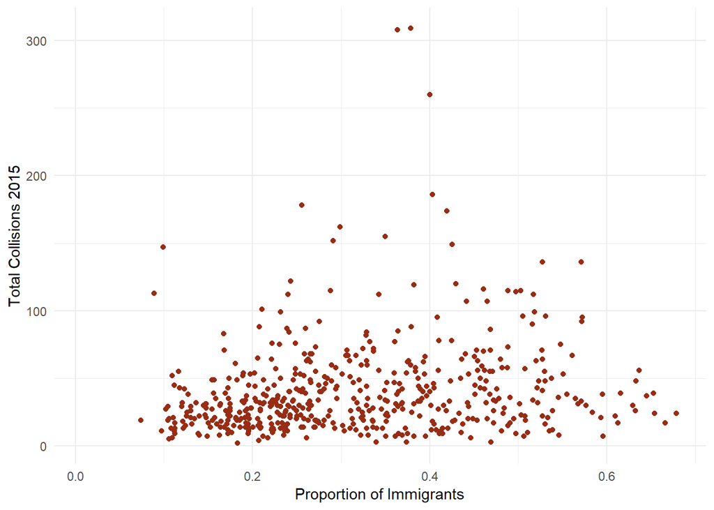

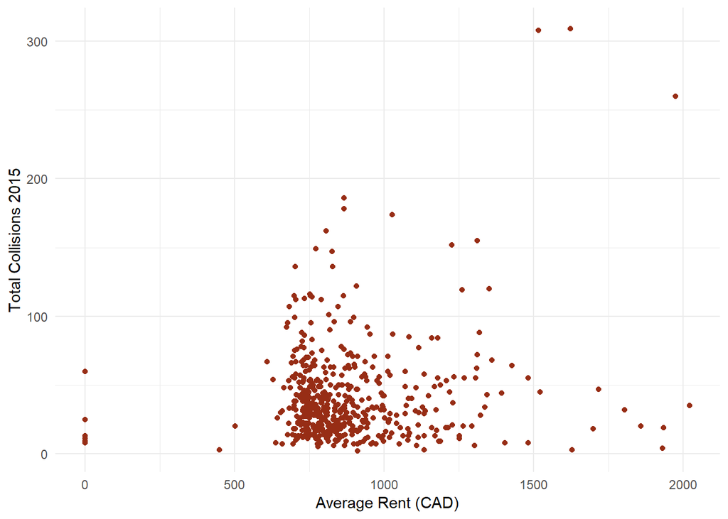

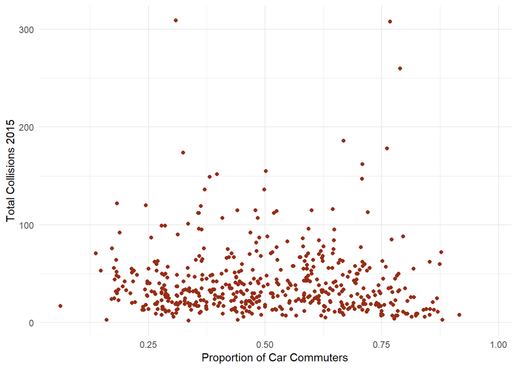

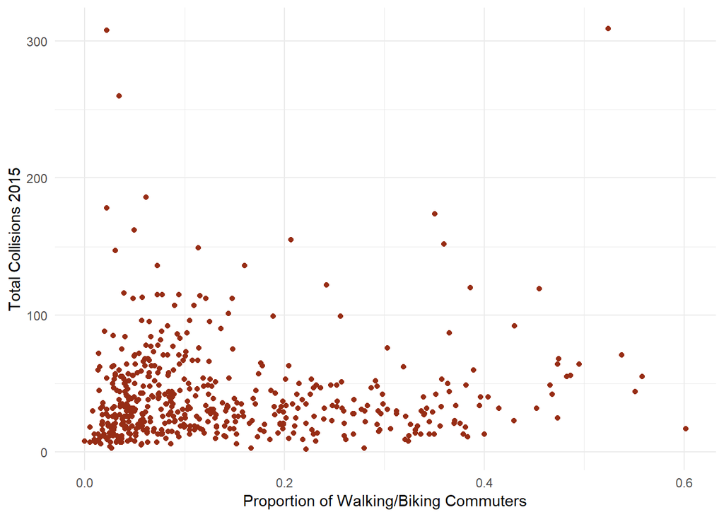